# E013 Pho4 chimera activity analysis using PHO5 reporter, pool and QC

Bin He

2023-12-29 updated 2024-01-12

```r
require(plotly)
require(tidyverse)
require(ggridges)
require(cowplot)
require(RColorBrewer)
```

```r
old <- theme_set(theme_bw(base_size = 16))
```

# Goal

- Analyze the full chimera set flow results for *PHO5pr*-mCherry reporter.
- Develop an analysis pipeline to perform QC, correction (if needed) and plotting the results.
- Compared with the 2023-10-19 analysis of the same type, this one incorporates new data in the *PHO5* background generated by Lindsey on 12/28 and 12/29, including new chimeras to make a complete set for the new 4/5 breakpoints.

# Data

Import the data

```r
files <- list.files(path = "../input/PHO5-data", pattern = "*-gated-median-out.txt")
names <- gsub("-gated-median-out.txt", "", files)
files <- paste0("../input/PHO5-data/", files)
names(files) <- names
raw <- map_dfr(files, ~read_tsv(.x, col_types = cols()), .id = "date") %>%
  mutate(
    flag = ifelse(is.na(flag), # if no flag was recorded in the original gated median data
                  ifelse(n_induction < 1000, "fail", "pass"), # fail if fewer than 1000 events
                  flag), # if the original data (one) has flag, use it
    plate = ifelse(grepl("-b", date), "B", "A"), # two plates a day
    date = format(ymd(date), "%m/%d")
  ) %>%
  relocate(plate, .after = date) %>%
  filter(!grepl("bead", sample)) %>%
  separate(col = sample, sep = "-", into = c("plasmid", "host", "rep"))
```

Sample information

```r
sample <- read_tsv("../input/20231228-chimera-Pho4-makeup.txt",
                   col_types = "ccccc", comment = "#")
```

# QC

## 1. Number of events per sample

Blank wells are indeed blank

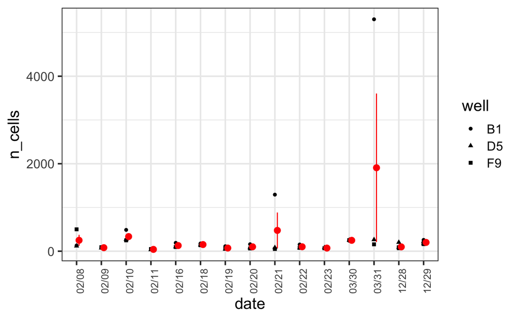

```r
raw %>% filter(host == "blank") %>%
  group_by(date) %>%
  ggplot(aes(x = date, y = n_cells)) + geom_point(aes(shape = well)) +
  stat_summary(fun.data = "mean_se", geom = "pointrange", color = "red",
               position = position_nudge(x = 0.1)) +
  theme_bw(base_size = 16) + theme(axis.text.x = element_text(size = rel(0.8), angle = 90))
```

> there are some cell like events in the blank wells, especially in one well on 02/21 and another on 3/31. 02/08 and 02/10 also have more events than other days. checking the pre-processing R notebook outputs, I think there may be some carry over between wells. No wide spread contamination though.

Below, we will remove the blank wells from further consideration

```r
tmp <- filter(raw, host != "blank")
```

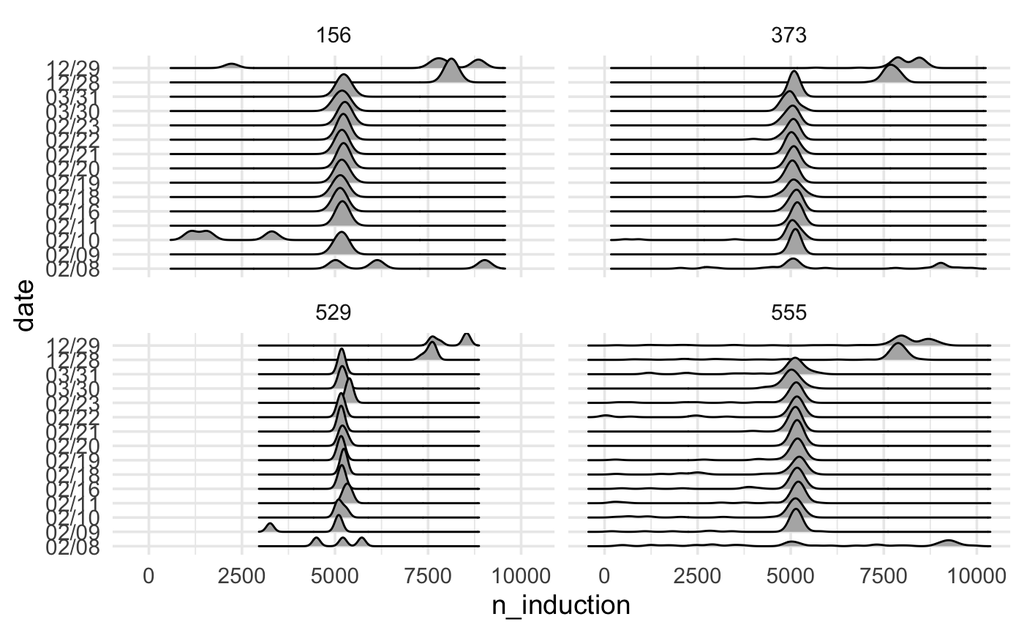

```r
tmp %>%
  ggplot(aes(x = n_induction)) +
  #geom_histogram(bins = 30, fill = "forestgreen") + facet_grid(host~date) +
  geom_density_ridges(aes(y = date)) +
  facet_wrap(~host) + theme_minimal(base_size = 14) #+ panel_border()
```

> Majority of the experimental wells (not blank) have > 5000 events, with the exception of a few samples The new data on 12/28 and 12/29 have more events on average

```r
tmp %>% filter(n_induction < 1000)
```

| date | plate | well | plasmid | host | rep | name | n_root | n_cells | n_singlet | n_induction | FSC.H | BL1.H | YL2.H | nGFP | nRFP | flag |
| --- | --- | --- | --- | --- | --- | --- | --- | --- | --- | --- | --- | --- | --- | --- | --- | --- |
| 02/08 | A | E4 | 234 | 555 | 3 | 234-555-3 | 3322 | 2906 | 472 | 412 | 511484.5 | 2454.0 | 43571.5 | 2403.5 | 42379.3 | fail |
| 02/08 | A | G8 | 239 | 555 | 3 | 239-555-3 | 15477 | 15090 | 5579 | 556 | 492286.5 | 2453.0 | 30833.0 | 2570.9 | 32283.9 | fail |
| 02/09 | A | G12 | 239 | 555 | 3 | 239-555-3 | 16379 | 15893 | 5281 | 199 | 460918.0 | 2599.0 | 24221.0 | 2863.6 | 27611.6 | fail |
| 02/10 | A | B9 | NA | 373 | 3 | NA-373-3 | 6363 | 5213 | 991 | 915 | 494967.0 | 1884.0 | 950.0 | 1928.1 | 1065.3 | fail |
| 02/10 | A | F5 | NA | 555 | 2 | NA-555-2 | 5071 | 4116 | 687 | 627 | 472499.0 | 1574.0 | 514.0 | 1733.1 | 613.9 | fail |
| 02/10 | A | G3 | 218 | 555 | 2 | 218-555-2 | 4714 | 4024 | 1115 | 700 | 489888.5 | 3892.0 | 58380.5 | 4188.6 | 63282.4 | fail |
| 02/10 | A | G4 | 218 | 555 | 3 | 218-555-3 | 2284 | 1895 | 386 | 316 | 468865.5 | 3968.0 | 63623.0 | 4370.8 | 70751.3 | fail |
| 02/10 | A | H5 | NA | 373 | 2 | NA-373-2 | 5943 | 4818 | 611 | 558 | 410619.5 | 1514.0 | 721.5 | 1751.0 | 923.2 | fail |
| 02/11 | A | G6 | 218 | 555 | 1 | 218-555-1 | 2067 | 1821 | 304 | 260 | 466364.5 | 4032.5 | 66703.5 | 4623.5 | 76566.3 | fail |
| 02/11 | A | G7 | 218 | 555 | 2 | 218-555-2 | 3337 | 3003 | 625 | 544 | 448210.0 | 3621.5 | 62006.0 | 4393.7 | 74692.9 | fail |

[output cut: 13 more lines]

Remove low event count and a few experiments with “fail” flag.

```r
dat <- filter(raw, host != "blank", flag == "pass")
```

## 2. Background subtraction

Check the background fluorescence levels across different days.

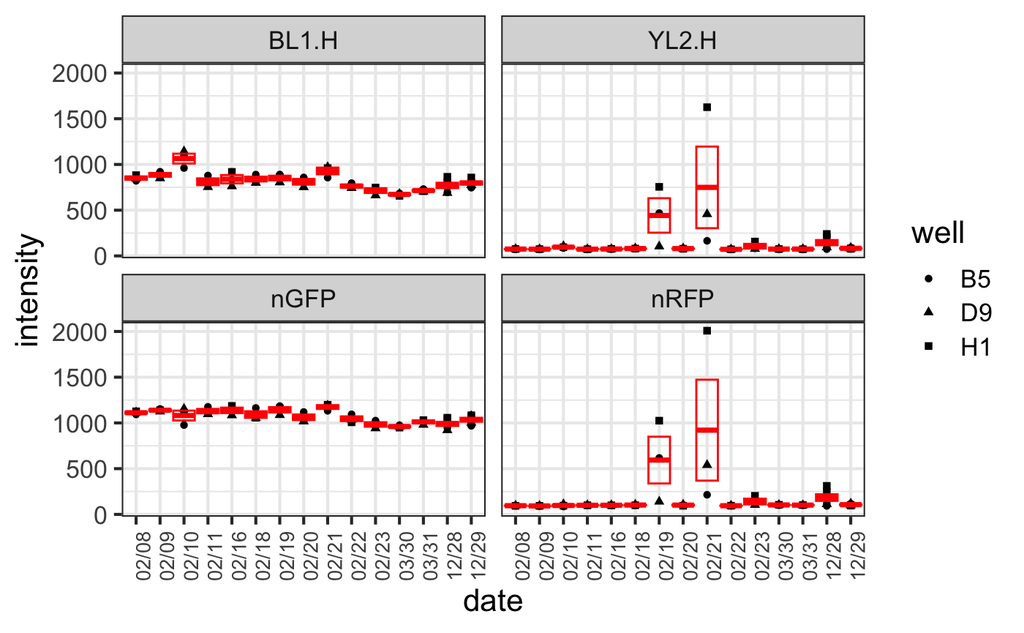

```r
dat %>% filter(host == "156") %>%
  pivot_longer(BL1.H:nRFP, names_to = "parameter", values_to = "intensity") %>%
  mutate(parameter = ordered(parameter, levels = c("BL1.H", "YL2.H", "nGFP", "nRFP"))) %>%
  ggplot(aes(x = date, y = intensity)) + geom_point(aes(shape = well)) +
  stat_summary(fun.data = "mean_se", geom = "crossbar", color = "red") +#,
               #position = position_nudge(x = 0.3)) +
  facet_wrap(~parameter) +
  theme_bw(base_size = 16) + theme(axis.text.x = element_text(size = rel(0.8), angle = 90))
```

> 12/28 has slightly elevated background, and there seems to be a well position effect.

```r
tmp <- dat %>% filter(host == "156")
lm(BL1.H ~ date, data = tmp) %>% anova()
```

```
Analysis of Variance Table

Response: BL1.H
          Df Sum Sq Mean Sq F value    Pr(>F)
date      14 394916 28208.3  9.7192 2.115e-08 ***
Residuals 36 104484  2902.3
---
Signif. codes:  0 ‘***’ 0.001 ‘**’ 0.01 ‘*’ 0.05 ‘.’ 0.1 ‘ ’ 1
```

> ANOVA above does reveal significant variation in GFP background fluorescence between yH156 across days.

Is there any relationship between the background BL1.H level from yH156 and mNeon levels from the experimental strains?

```r
test.strain = "194"
tmp <- dat %>%
  filter(grepl(paste0("NA-156|", test.strain, "-373"), name)) %>%
  group_by(date, plasmid) %>%
  summarize(meanGFP = mean(BL1.H), .groups = "drop") %>%
  pivot_wider(id_cols = date, names_from = plasmid, names_prefix = "p", values_from = meanGFP)

lm(p194 ~ pNA, data = tmp) %>% summary()
```

```
Call:
lm(formula = p194 ~ pNA, data = tmp)

Residuals:
    Min      1Q  Median      3Q     Max
-479.30  -90.81   49.56  131.46  193.07

Coefficients:
             Estimate Std. Error t value Pr(>|t|)
(Intercept) 2323.7839   436.0201   5.330 0.000137 ***
pNA           -0.3029     0.5277  -0.574 0.575741
---
Signif. codes:  0 ‘***’ 0.001 ‘**’ 0.01 ‘*’ 0.05 ‘.’ 0.1 ‘ ’ 1

Residual standard error: 189.4 on 13 degrees of freedom
Multiple R-squared:  0.02472,   Adjusted R-squared:  -0.0503
F-statistic: 0.3295 on 1 and 13 DF,  p-value: 0.5757
```

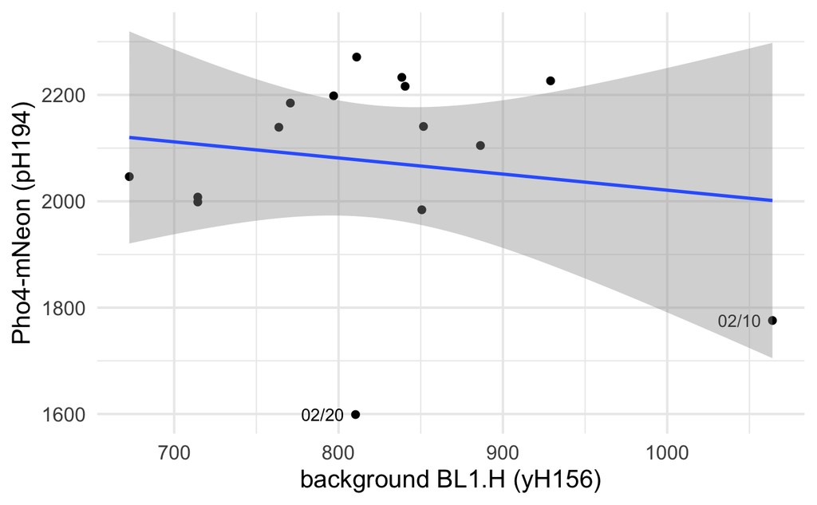

```r
p <- ggplot(tmp, aes(x = pNA, y = p194)) +
  geom_point(size = 2) +
  geom_text(data = filter(tmp, p194 < 1800), aes(label = date), nudge_x = -20) +
  stat_smooth(method = "lm", formula = y~x) +
  xlab("background BL1.H (yH156)") + ylab(paste0("Pho4-mNeon (pH", test.strain, ")")) +
  theme_minimal(base_size = 16)

p
```

> No strong correlation between the background and the mNeon levels

Given the results above, I propose to do the following:

[output not shown]

Subtract the background. For now, I’ll leave out the new 2023.12 data. They only affect the background values by ~6%. Shouldn’t affect the ratios afterwards.

```r
bg <- dat %>%
  filter(host == "156", !date %in% c("12/28", "12/29")) %>%
  group_by(date) %>%
  # average based on dates
  summarize(across(BL1.H:nRFP, ~ round(mean(.x),1)), .groups = "drop") %>%
  # median of day averages
  summarize(across(BL1.H:nRFP, ~median(.))) %>%
  unlist() # turn into a named vector storing background readings
  #column_to_rownames(var = "date")

bg.rm <- dat %>%
  select(date:host, events = n_induction, FSC.H:nRFP, flag) %>%
  mutate(
    BL1.H = BL1.H - bg["BL1.H"],
    YL2.H = YL2.H - bg["YL2.H"],
    nGFP = nGFP - bg["nGFP"],
    nRFP = nRFP - bg["nRFP"],
  )
```

Double check that the subtraction worked correctly

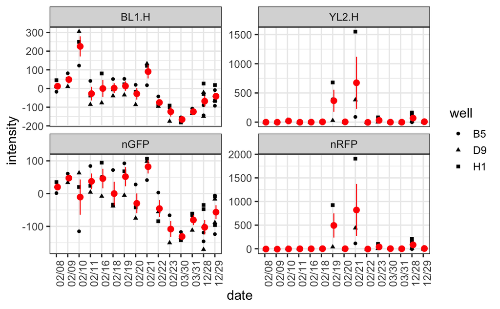

```r
bg.rm %>% filter(host == "156") %>%
  pivot_longer(BL1.H:nRFP, names_to = "parameter", values_to = "intensity") %>%
  mutate(parameter = ordered(parameter, levels = c("BL1.H", "YL2.H", "nGFP", "nRFP"))) %>%
  ggplot(aes(x = date, y = intensity)) + geom_point(aes(shape = well)) +
  stat_summary(fun.data = "mean_se", geom = "pointrange", color = "red", position = position_nudge(x = 0.1)) +
  facet_wrap(~parameter, scale = "free_y") +
  theme_bw(base_size = 14) + theme(axis.text.x = element_text(angle = 90))
```

Determine if any sample had very low mNeon levels despite having a Pho4 chimera plasmid. I observed such samples when doing the pre-processing, and would like to identify and remove them now.

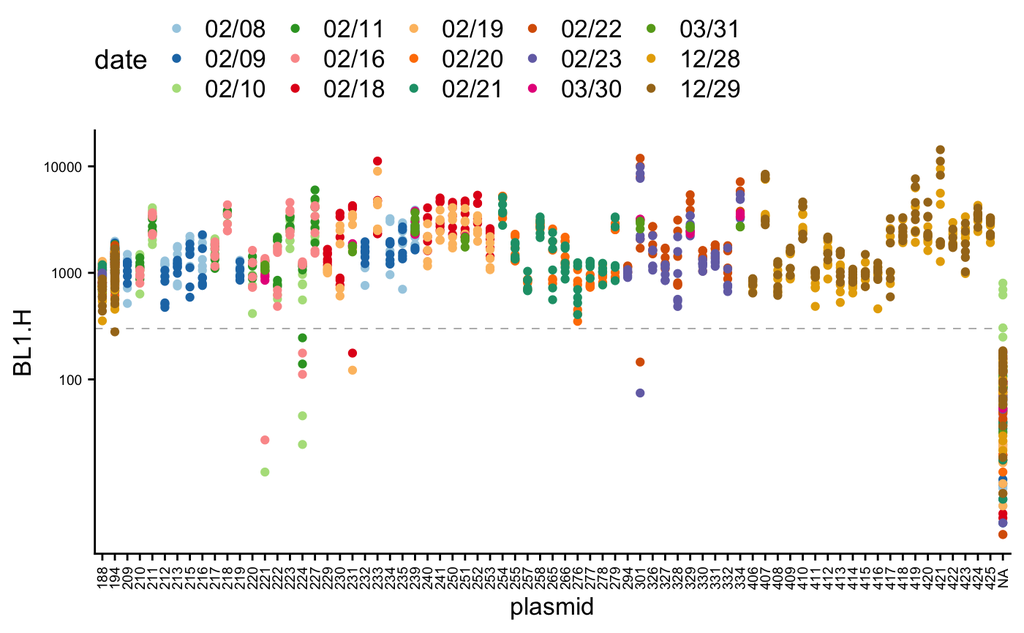

```r
mycolors = c(brewer.pal(name="Paired", n = 8), brewer.pal(name="Dark2", n = 8))

no.exn.th <- 300
ggplot(bg.rm, aes(x = plasmid, y = abs(BL1.H))) +
  geom_hline(yintercept = no.exn.th, color = "grey50", linetype = 2, linewidth = 0.2) +
  geom_point(aes(color = date)) +
  scale_y_log10(breaks = c(100, 1000, 10000)) + ylab("BL1.H") +
  scale_color_manual(values = mycolors) + theme_cowplot() +
  theme(axis.text.x = element_text(angle = 90, size = rel(0.6), vjust = 0.5),
        axis.text.y = element_text(size = rel(0.6)),
        axis.title = element_text(size = rel(0.9)),
        legend.text = element_text(size = rel(0.9)),
        legend.position = "top")
```

```r
# assign "fail" to the non-expressing ones
bg.rm[bg.rm$plasmid != "NA" & bg.rm$BL1.H < no.exn.th, "flag"] = "fail"
filter(bg.rm, flag == "fail")
```

| date | plate | well | plasmid | host | events | FSC.H | BL1.H | YL2.H | nGFP | nRFP | flag |
| --- | --- | --- | --- | --- | --- | --- | --- | --- | --- | --- | --- |
| 02/10 | A | C6 | 221 | 555 | 5220 | 397847.5 | 13.5 | 665.8 | 60.4 | 906.5 | fail |
| 02/10 | A | G6 | 224 | 555 | 5135 | 382947.0 | 24.5 | 505.3 | 139.8 | 724.4 | fail |
| 02/10 | A | G8 | 224 | 555 | 5020 | 384825.5 | 45.5 | 512.3 | 161.3 | 742.4 | fail |
| 02/11 | A | C10 | 224 | 555 | 5297 | 387279.0 | 139.5 | 737.3 | 262.4 | 1026.4 | fail |
| 02/11 | A | C12 | 224 | 555 | 5047 | 407891.0 | 245.5 | 818.3 | 323.7 | 1066.3 | fail |
| 02/16 | A | C10 | 224 | 555 | 5283 | 398011.0 | 111.5 | 526.3 | 201.7 | 730.0 | fail |
| 02/16 | A | C12 | 224 | 555 | 5349 | 406480.0 | 176.5 | 571.3 | 258.1 | 754.1 | fail |
| 02/16 | A | G10 | 221 | 555 | 5168 | 388833.0 | 27.0 | 558.3 | 119.4 | 800.9 | fail |
| 02/18 | A | E2 | 231 | 555 | 5319 | 392590.0 | 176.5 | 3252.3 | 312.9 | 4426.0 | fail |
| 02/19 | A | C6 | 231 | 555 | 5282 | 373334.5 | 122.0 | 2772.8 | 307.6 | 4024.8 | fail |

[output cut: 3 more lines]

> the above samples will be exported for archiving, but won’t be used in subsequent analyses.

Lastly, pH231 assayed on 2/18 and 2/19 exhibited abnormal behaviors.

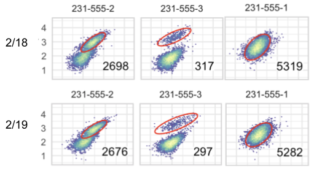

```r
bg.rm[bg.rm$plasmid == "231" & bg.rm$host == "555" & bg.rm$date %in% c("02/18", "02/19"), "flag"] = "fail"
filter(bg.rm, flag == "fail")
```

| date | plate | well | plasmid | host | events | FSC.H | BL1.H | YL2.H | nGFP | nRFP | flag |
| --- | --- | --- | --- | --- | --- | --- | --- | --- | --- | --- | --- |
| 02/10 | A | C6 | 221 | 555 | 5220 | 397847.5 | 13.5 | 665.8 | 60.4 | 906.5 | fail |
| 02/10 | A | G6 | 224 | 555 | 5135 | 382947.0 | 24.5 | 505.3 | 139.8 | 724.4 | fail |
| 02/10 | A | G8 | 224 | 555 | 5020 | 384825.5 | 45.5 | 512.3 | 161.3 | 742.4 | fail |
| 02/11 | A | C10 | 224 | 555 | 5297 | 387279.0 | 139.5 | 737.3 | 262.4 | 1026.4 | fail |
| 02/11 | A | C12 | 224 | 555 | 5047 | 407891.0 | 245.5 | 818.3 | 323.7 | 1066.3 | fail |
| 02/16 | A | C10 | 224 | 555 | 5283 | 398011.0 | 111.5 | 526.3 | 201.7 | 730.0 | fail |
| 02/16 | A | C12 | 224 | 555 | 5349 | 406480.0 | 176.5 | 571.3 | 258.1 | 754.1 | fail |
| 02/16 | A | G10 | 221 | 555 | 5168 | 388833.0 | 27.0 | 558.3 | 119.4 | 800.9 | fail |
| 02/18 | A | E2 | 231 | 555 | 5319 | 392590.0 | 176.5 | 3252.3 | 312.9 | 4426.0 | fail |
| 02/18 | A | E3 | 231 | 555 | 2698 | 433309.0 | 1713.0 | 7330.8 | 2111.3 | 9364.1 | fail |

[output cut: 5 more lines]

Export the background-subtracted values for later use with the shinyapp

```r
# remove the yH156 samples
dat.export <- bg.rm %>%
  filter(host != "156") %>%
  mutate(
    host = ordered(host, levels = c("555", "373", "529"), labels = c("PHO2", "pho2∆", "PHO84"))
  )

# set flag to fail for 2/10 data. see 3. consistency across plates
# for reason
dat.export %>%
  mutate(flag = ifelse(date == "02/10", "fail", flag)) %>%
  write_tsv("../input/20231230-PHO5-bg-subtracted-data.tsv")
```

## 3. Consistency across plates.

Check the background-subtracted fluorescence values for the host strains (yH373 and yH555) as well as the positive control strain (pH188 in yH373 or yH555 backgrounds), both of which are present on each plate.

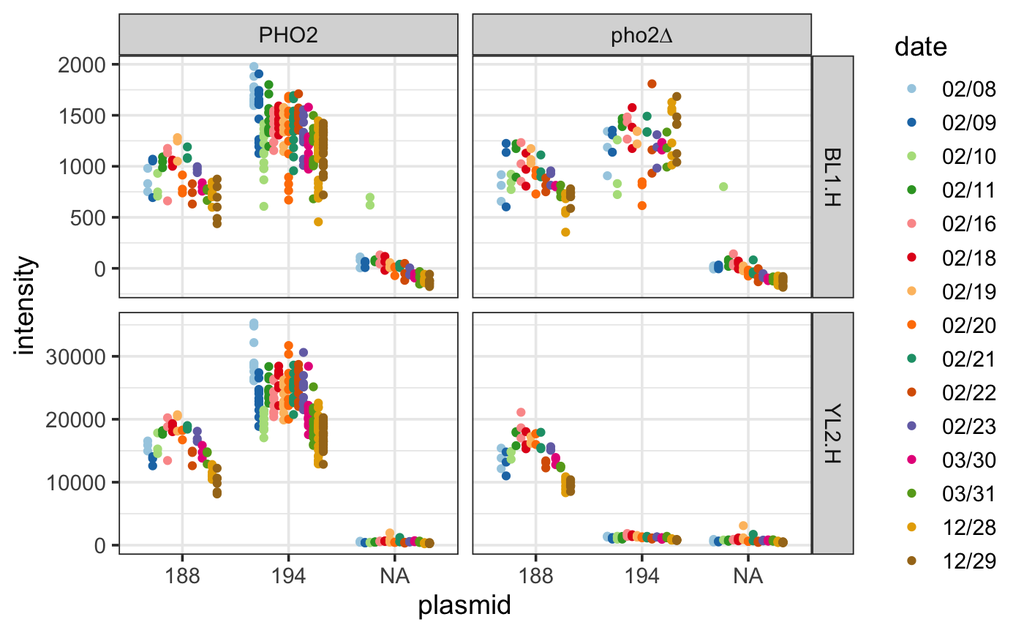

```r
dat.export %>%
  filter(host != "PHO84", flag == "pass", plasmid %in% c("188", "194", "NA")) %>%
  pivot_longer(BL1.H:YL2.H, names_to = "parameter", values_to = "intensity") %>%
  #mutate(parameter = ordered(parameter, levels = c("BL1.H", "YL2.H", "nGFP", "nRFP"))) %>%
  ggplot(aes(x = plasmid, y = intensity, group = date)) +
  geom_point(aes(color = date), position = position_dodge(0.7)) +
  scale_color_manual(values = mycolors) +
  facet_grid(parameter~host, scale = "free_y") +
  theme_bw(base_size = 14)# +
```

```r
  #theme(axis.text.x = element_text(face = 3))
```

> 1. The host strain fluorescence levels appear to be consistent across the days. Additionally, their GFP levels are zero, as expected.
> 2. The positive control strain has strong BL1.H and correspondingly has strong YL2.H.
> 3. 02/10 batch has strange BL1 values. Since we have three identical sets (02/10, 11, 16), we can ignore this batch in the downstream analysis

```r
dat.wide.fil <- filter(dat.export, host != "PHO84", flag == "pass", date != "02/10")
```

Number of replicates left for each sample

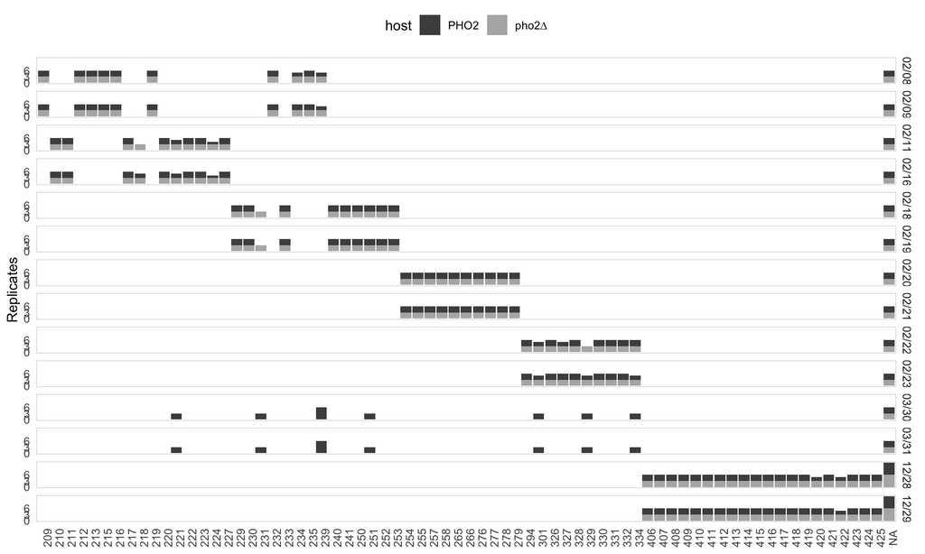

```r
expt <- dat.wide.fil %>%
  filter(host %in% c("PHO2", "pho2∆"), !plasmid %in% c("188", "194")) %>%
  group_by(date, plasmid, host) %>%
  summarize(n = n(), .groups = "drop")

expt %>%
  ggplot(aes(x = plasmid, y = n)) +
  geom_col(aes(fill = host)) +
  facet_grid(date ~ .) +
  scale_fill_manual(values = c("PHO2" = "gray30", "pho2∆" = "gray70")) +
  theme_minimal() + background_grid(major = "none") + panel_border(size = 0.5) +
  scale_y_continuous(name = "Replicates", breaks = c(0, 3, 6)) + xlab(NULL) +
  theme(axis.text.x = element_text(angle = 90),
        legend.position = "top")
```

How many plasmid-host combination have < 3 replicates after removing samples with low event counts?

```r
dat.wide.fil %>%
  count(plasmid, host) %>%
  filter(n < 3)
```

| plasmid | host | n |
| --- | --- | --- |
| 218 | PHO2 | 2 |
| 224 | PHO2 | 2 |

## 4. Well position

*Rationale*

- In my original plate design, I placed a positive control strain (envisioned CgPho4-mNeon in *PHO2* background for example) in the control columns (1, 5, 9) on every other row (A, C, E, G). The reason for this is to use it to identify any well position effect on the fluorescence readings.
- In Emily’s implementation, she instead put **a pair** of strains, namely pH188-yH323 and pH188-yH555 in these wells. This means I cannot use the positive control wells exactly the way as I designed them. But I can still use them to spot any trend.

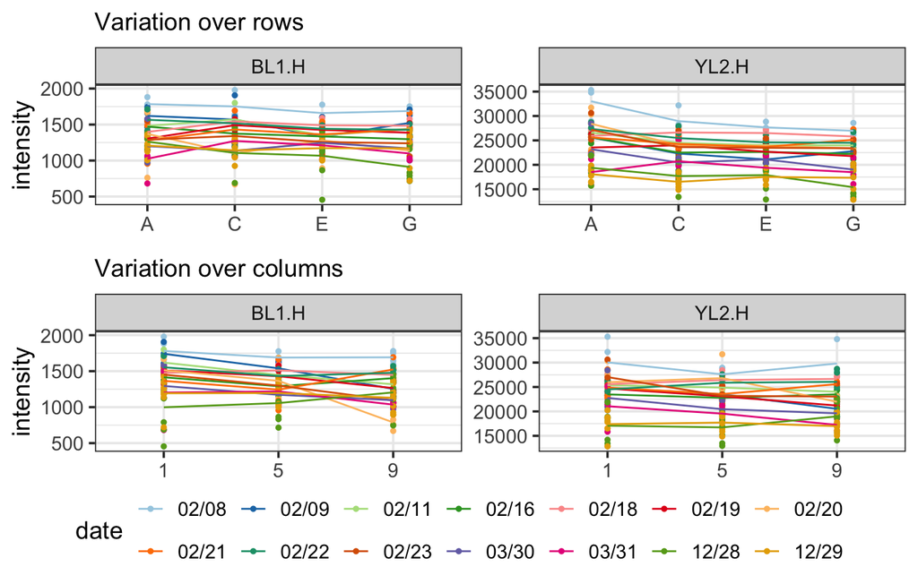

```r
tmp <- dat.wide.fil %>%
  filter(plasmid == "194", host == "PHO2") %>%
  separate(well, into = c("row", "col"), sep = 1) %>%
  pivot_longer(BL1.H:YL2.H, names_to = "parameter", values_to = "intensity")

p0 <- list(
  geom_point(aes(color = date), size = 1),
  #geom_line(aes(color = date), size = 0.4),
  stat_summary(aes(color = date), geom = "line", fun = mean, linewidth = 0.5),
  scale_color_manual(values = mycolors),
  #scale_color_brewer(type = "qual", palette = 2),
  facet_wrap(~parameter, scales = "free_y"),
  xlab(NULL),
  guides(color = guide_legend(title.position = "left", nrow = 2, byrow = TRUE)),
  theme_bw(base_size = 14),
  theme(legend.text = element_text(size = rel(0.8)))
)

p1 <- ggplot(tmp, aes(x = row, y = intensity, group = date)) + p0 +
  labs(subtitle = "Variation over rows")

p2 <- ggplot(tmp, aes(x = col, y = intensity, group = date)) + p0 +
  labs(subtitle = "Variation over columns")

p.legend <- get_legend(p1)

plot_grid(p1 + guides(color = "none"), p2 + guides(color = "none"), p.legend,
          nrow = 3, rel_heights = c(1,1,0.3))
```

> - no obivous trend between the rows; there seems to be downward trend for BL1 going from column 1 to 9
> - a clear correlation between YL2.H and BL1.H. at least part of this is due to the cell size differences – see size normalized data below:
- What we care about is the ratio between Pho4-mNeon and *PHO5pr*-mCherry

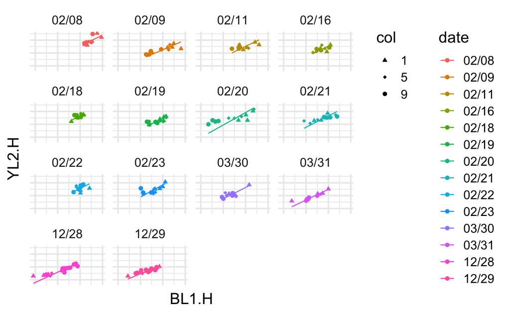

```r
tmp <- dat.wide.fil %>%
  filter(plasmid == "194", host == "PHO2") %>%
  separate(well, into = c("row", "col"), sep = 1)

tmp %>%
  ggplot(aes(x = BL1.H, y = YL2.H)) +
  stat_smooth(aes(color = date, group = date),
              method = "lm", formula = y ~ 0 + x,
              se = FALSE, size = 0.5) +
  geom_point(aes(color = date, shape = col), size = 1.5) +
  #scale_color_manual(values = mycolors) +
  scale_shape_manual(values = 17:19) +
  facet_wrap(~ date) +
  theme_minimal(base_size = 16) +
  theme(axis.text = element_blank(),
        legend.position = "right",
        legend.box = "horizontal")
```

> There is variation in BL1.H and correspondingly in YL2.H, but the ratio between the two are very consistent 02/20 data is a bit of an outlier

Let’s check both ScPho4 (pH194) and CgPho4 (pH188) to see if their behaviors are consistent across the days.

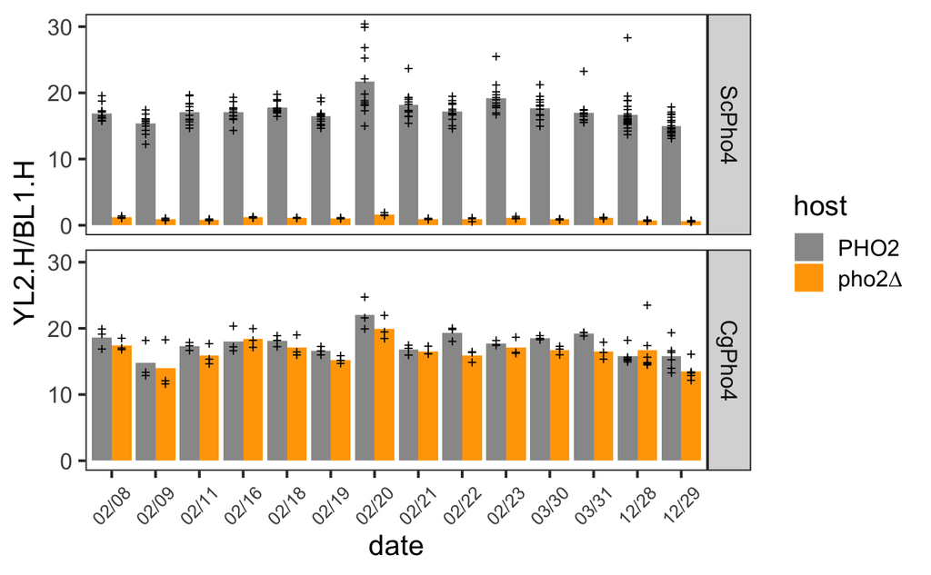

```r
dat.wide.fil %>%
  filter(plasmid %in% c("188", "194"), host != "PHO84") %>%
  mutate(`YL2.H/BL1.H` = YL2.H/BL1.H,
         Pho4 = factor(plasmid, levels = c("194", "188"),
                       labels = c("ScPho4", "CgPho4"))) %>%
  separate(well, into = c("row", "col"), sep = 1) %>%
  ggplot(aes(x = date, y = `YL2.H/BL1.H`)) +
  geom_bar(aes(fill = host), stat = "summary", fun = "mean",
           position = position_dodge(0.9)) +
  geom_point(aes(group = host), size = 1, shape = 3,
             position = position_dodge(width = 0.9)) +
  scale_fill_manual(values = c("PHO2" = "gray60", "pho2∆" = "orange")) +
  #stat_summary(fun.data = "mean_se", geom = "pointrange", color = "red") +
  facet_grid(Pho4 ~ .) +
  theme_bw(base_size = 16) + background_grid(major = "none") +
  theme(axis.text.x = element_text(size = rel(.8), angle = 45, vjust = 0.5))
```

> 2/20 data is more variable (also see the figure above the one immediately above)

## 5. High variance samples

Summarize the background subtracted data by calculating the means and cv for each strain.

```r
cv <- dat.wide.fil %>%
  select(-nGFP, -nRFP) %>%
  pivot_longer(FSC.H:YL2.H, names_to = "parameter", values_to = "intensity") %>%
  group_by(date, plasmid, host, parameter) %>%
  summarize(
    n = n(),
    mean = mean(intensity),
    cv = sd(intensity)/mean(intensity),
    .groups = "drop"
  ) %>%
  arrange(desc(cv))
```

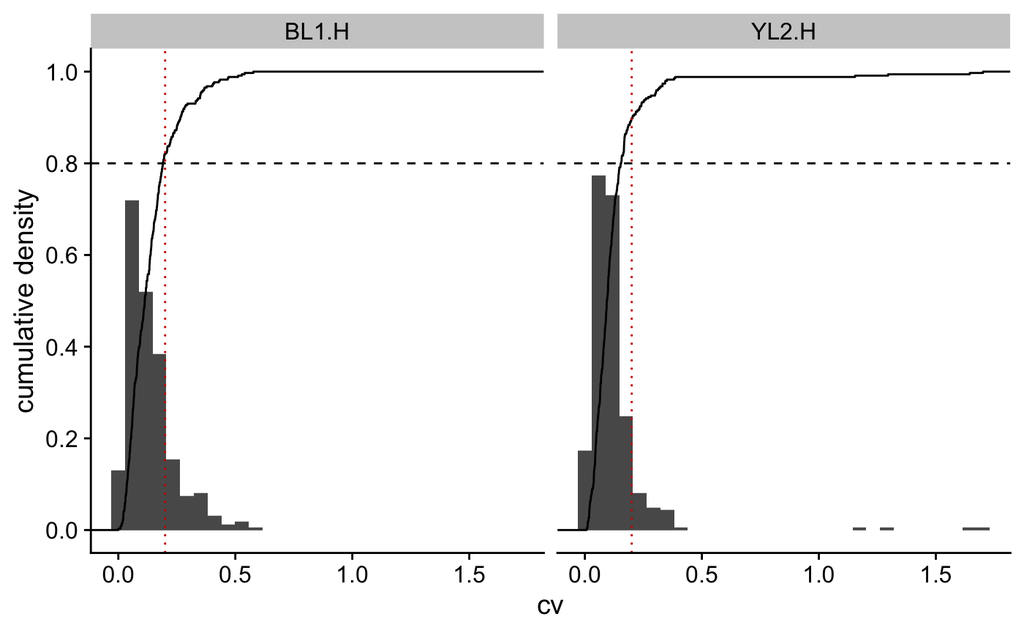

```r
cv %>%
  filter(plasmid != "NA", parameter != "FSC.H") %>%
  ggplot(aes(x = cv)) + geom_histogram(aes(y = after_stat(density)/8), bins = 30) +
  stat_ecdf() +
  geom_hline(yintercept = 0.8, linetype = 2) +
  geom_vline(xintercept = 0.2, linetype = 3, color = "red3") +
  scale_y_continuous(breaks = seq(0, 1, by = 0.2)) +
  ylab("cumulative density") +
  facet_wrap(~parameter) +
  theme_cowplot()
```

> The histogram’s y-axis is not shown. The line graph represents the empirical CDF, and the dotted horizontal line is at 80%. GFP is more variable than RFP, likely because the absolute values of the former is lower. For both, ~80% of the samples have a CV < 20%.

Do the same for the cell size-normalized values

```r
cv.n <- dat.wide.fil %>%
  select(-BL1.H, -YL2.H) %>%
  pivot_longer(nGFP:nRFP, names_to = "parameter", values_to = "intensity") %>%
  group_by(date, plasmid, host, parameter) %>%
  summarize(
    n = n(),
    mean = num(mean(intensity), digits = 0),
    cv = num(sd(intensity)/mean(intensity), digits = 2),
    .groups = "drop"
  ) %>%
  arrange(desc(cv))
```

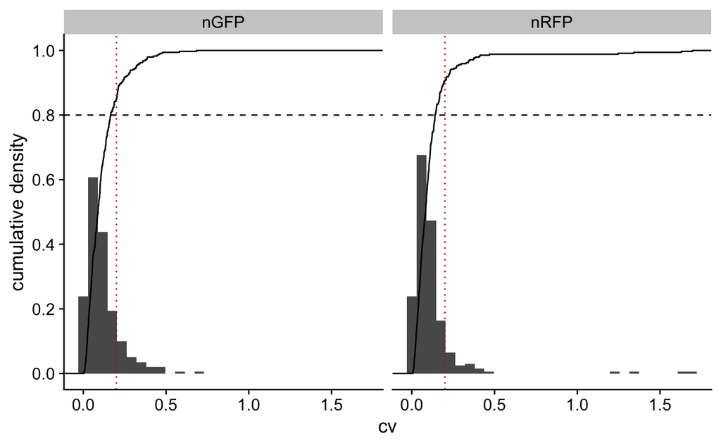

```r
cv.n %>%
  filter(plasmid != "NA", parameter != "FSC.H") %>%
  ggplot(aes(x = cv)) + geom_histogram(aes(y = after_stat(density)/10), bins = 30) +
  stat_ecdf() +
  geom_hline(yintercept = 0.8, linetype = 2) +
  geom_vline(xintercept = 0.2, linetype = 3, color = "red3") +
  scale_y_continuous(breaks = seq(0, 1, by = 0.2)) +
  ylab("cumulative density") +
  facet_wrap(~parameter) +
  theme_cowplot()
```

> CV is about the same for the size normalized data.

Identify the high variance samples

```r
high.var.list <- cv %>%
  mutate(CV = round(abs(cv), 3)) %>%
  pivot_wider(id_cols = c(date, plasmid, host),
              names_from = parameter, names_prefix = "CV_",
              values_from = CV) %>%
  filter(CV_BL1.H > 0.2 | CV_YL2.H > 0.2) %>%
  arrange(date, plasmid, host)
dat.high.var <- left_join(high.var.list, dat.wide.fil) %>% select(-flag) %>% arrange(date, plasmid)
write_tsv(dat.high.var, "../input/PHO5-data/20240103-high-var-samples.tsv")

dat.high.var %>% filter((CV_BL1.H > 1 & plasmid != "NA") | CV_YL2.H > 1)
```

| date | plasmid | host | CV_YL2.H | CV_BL1.H | CV_FSC.H | plate | well | events | FSC.H | BL1.H | YL2.H | nGFP | nRFP |
| --- | --- | --- | --- | --- | --- | --- | --- | --- | --- | --- | --- | --- | --- |
| 02/18 | 233 | pho2∆ | 1.296 | 0.540 | 0.060 | A | H2 | 4948 | 413935.5 | 4710.5 | 906.3 | 5864.0 | 1173.6 |
| 02/18 | 233 | pho2∆ | 1.296 | 0.540 | 0.060 | A | H3 | 5178 | 407518.0 | 4790.0 | 955.3 | 6129.3 | 1287.9 |
| 02/18 | 233 | pho2∆ | 1.296 | 0.540 | 0.060 | A | H4 | 5102 | 369971.5 | 11201.0 | 9227.3 | 17732.2 | 13920.7 |
| 02/19 | 233 | pho2∆ | 1.155 | 0.430 | 0.094 | A | D10 | 4834 | 391435.5 | 4349.0 | 1230.8 | 5846.1 | 1721.3 |
| 02/19 | 233 | pho2∆ | 1.155 | 0.430 | 0.094 | A | D11 | 4993 | 391237.0 | 4712.5 | 1001.3 | 6402.3 | 1380.7 |
| 02/19 | 233 | pho2∆ | 1.155 | 0.430 | 0.094 | A | D12 | 5008 | 331057.5 | 8998.0 | 7807.8 | 15378.5 | 13498.3 |
| 12/28 | 423 | PHO2 | 1.645 | 0.577 | 0.121 | B | C10 | 8040 | 382169.0 | 1887.0 | 509.3 | 2725.6 | 733.7 |
| 12/28 | 423 | PHO2 | 1.645 | 0.577 | 0.121 | B | C11 | 8241 | 371740.0 | 984.5 | 758.3 | 1494.3 | 1101.9 |
| 12/28 | 423 | PHO2 | 1.645 | 0.577 | 0.121 | B | C12 | 2129 | 461502.0 | 3358.5 | 36473.3 | 4051.7 | 43977.8 |
| 12/29 | 423 | PHO2 | 1.702 | 0.528 | 0.114 | B | G6 | 8822 | 387864.5 | 1588.5 | 220.3 | 2252.5 | 308.4 |

[output cut: 2 more lines]

> plasmid 233 replicates 1 & 2 repeatedly showed no RFP induction, while replicate 3 did show induction. A similar situation was found for 423